# Midterm Project

11/25/2019

## Data Prep

- Removed NA/blank columns including the ‘filler’ columns
- Filtered for admission years of 2016, 2017, and 2018
- Corrected the classes of columns (i.e. changing sex to factor)

## Length of Stay, by Gender and Age

Length of stay is generally more variable for patients who are younger. Also more variable in 2016 than in 2018.

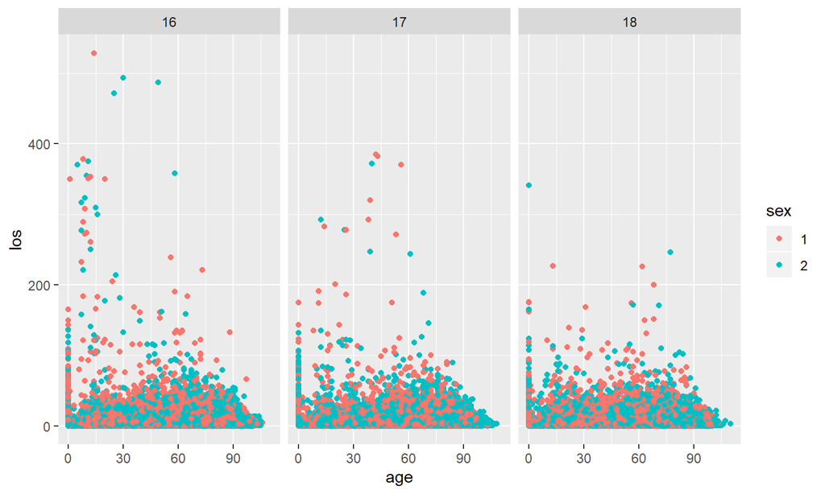

## Total Cost, by Gender

Slightly wider distribution for males, but about the same average.

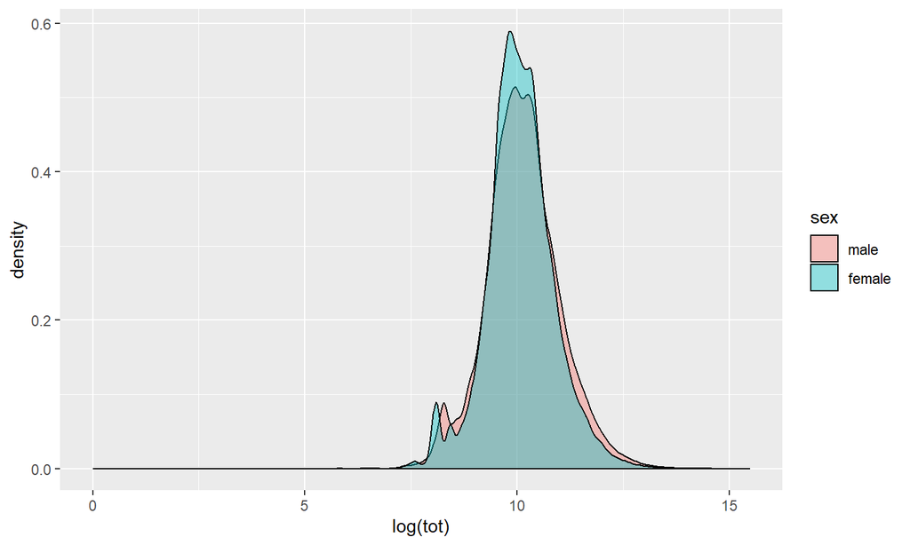

## Cost Categories

On average, pharmacy costs decreasing. Diagnostic tests increasing by the most.

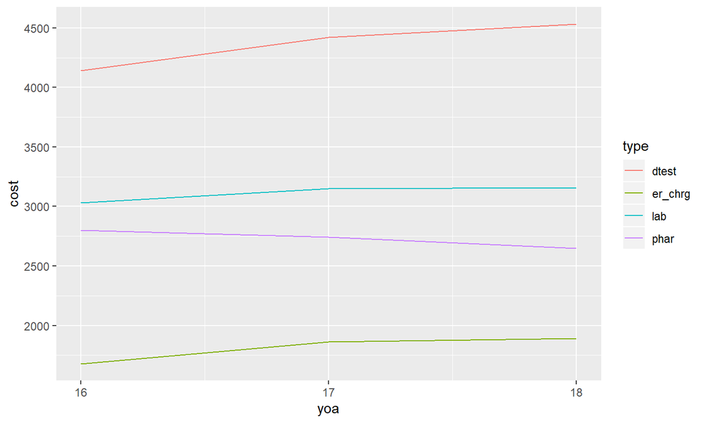

## ER Charges, by Race and Gender

Males have higher ER charges than females across all races.

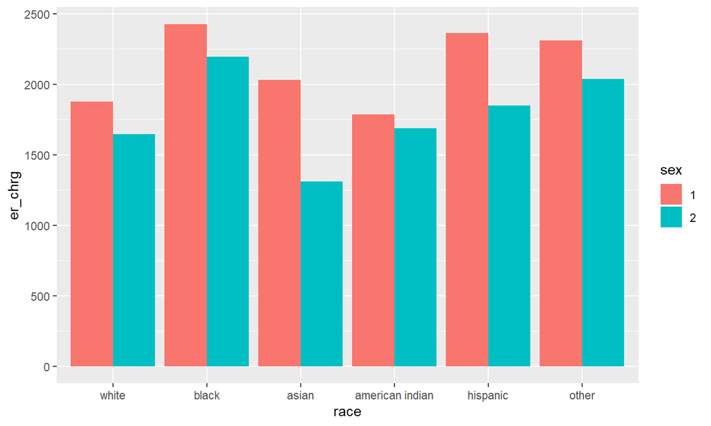

## Data Prep for Modeling

- For dx1 and dx2, added another column indicating the frequency of that diagnosis
- Used this freqency column to classify the diagnosis into quartiles (higher quartile = more freqent diagnosis)
- Created a binary target indicating whether length of stay was at least 4 days
- Included variables: los_ind, age, pay_ub92, sex, raceethn, provider, moa, admtype, service, quant_dx1, quant_dx2, yoa, payer

## Training and Testing

- Sampled a random 10,000 observations from the prepped data
- Used 70/30 split for training and testing

## Models

- Decision Tree: 0.5952
- Random Forest: 0.5911
- K-Nearest Neighbors: 0.5581
- GLM Binomial: 0.5817
- GBM: 0.6040

## Tuning

- Tree:
- Tried max depths of 3, 7, and 12
- Used 10-fold cross validation
- Chose 7 for max depth
- Forest:
- Tried # variables 5, 7, and 10
- Tried min node size of 50, 100, and 150
- Used 7-fold cross validation repeated 3 times
- Chose 7 for # variables and 100 for node size

## Tuning

- Tried interaction depth of 3 and 6
- Tried min observations in node of 50 and 75
- Chose interaction depth of 3 and min node size of 50

## Next Steps

- was not able to get above 0.7 accuracy
- look into collecting more data at time of admission that could be incorporated
- more in depth-tuning or the use of more complex models